# Tarea intervalos de confianza

Arturo Bell Enríquez García

## Tips para realizar la tarea:

¡Hola chicos! Al parecer no me explique bien con respecto a la tarea, entonces tomen esta libreta como un ejemplo sobre cuál es el objetivo. Recuerden que parte del trabajo en las tareas es que ustedes aprendan por sí mismos revisando la ayuda de las funciones o realizando sus propias búsquedas.

Algunos tips para que no sufran demasiado:

1. Consideren que los individuos de la base de datos son **toda la población**.
2. Piensen en qué es mejor, un muestreo con reemplazo (regresar los organismos a la pecera después de haberlos medido) o sin reemplazo (una vez medidos ya no son considerados) para hacer las estimaciones y cómo especificarle eso a la función `sample()`
3. Su `data.frame` final pueden armarlo renglón a renglón (función `rbind()`, hay un ejemplo en la libreta de la clase de probabilidad) o columna a columna (función `data.frame`, como lo vimos en la clase de introducción a R). Si quieren dar un paso de gigante, pueden utilizar un ciclo `for`. En la libreta de la clase de probabilidad hay un ejemplo de cómo utilizarlo. Piensen en esa función como un búcle en el cual la computadora ciclará por los elementos de una variable y realizará una serie de acciones según lo que esta contenga. Una alternativa más es utilizar alguna de las funciones de la familia `apply` y sus relativas (`apply()`, `lapply()`, `tapply()`, `sapply()`, `rep()`, `mapply()`, `Sweep()` o `aggregate()`).
4. Únicamente estimen los intervalos de confianza utlizando una sola función, vean cuál es la salida y piensen en cómo accesar ese tipo de objeto para poder recuperar solo la información que necesiten.
5. En la tarea solicito el HTML de su libreta. Ese se genera cuando crean la libreta y la guardan por primera vez. Para actualizar su contenido solo necesitan guardar su archivo .Rmd.

Por último, si tienen una idea más o menos bosquejada y necesitan orientación para llevarla a cabo, no duden en contactarme.

¡Mucho éxito!

## Descripción

Para la tarea de esta semana cargarán el archivo `Datos1.csv` con el código aquí incluído y, de manera similar a como se vio durante la clase, realizarán la estimación de la media, la desviación estándar y los intervalos de confianza (utilizando cualquiera de las formas aquí vistas) para diferentes tamaños de muestra (ojo a la función `sample()`). El objetivo es ver cómo cambian tanto la estimación puntual como la amplitud de los intervalos al incrementar el tamaño de muestra.

Parte **OPCIONAL**:Si quieres desafiarte un poco más, considera alguna de las variables Dieta o Periodo como un “estrato” dentro de la población y realiza las estimaciones con esa consideración. Puedes también intentar presentar los resultados de manera gráfica (estratificados o no). Una alternativa es usar un gráfico KDE y mostrar los límites como líneas verticales, otra alternativa es un gráfico similar al que se presentó en clase, con el número de muestras en el eje x y un gráfico con líneas de error para el eje y. Este apartado OPCIONAL no tiene una “respuesta correcta” ni será considerado para la evaluación, así que puedes experimentar y presentar (o no) los resultados de la manera en que tú consideres se resuelven los objetivos.

## Procedimiento

### Carga de los datos

```r
df <- read.table("Datos1.csv", header = F, skip = 1, sep = ",")
colnames(df) <- c("Dieta", "Periodo", "Rep", "LT", "PT")
head(df)
```

|  | Dieta | Periodo | Rep | LT | PT |
| --- | --- | --- | --- | --- | --- |
| 1 | A | I | A | 0.883 | 0.50 |
| 2 | A | I | A | 0.909 | 0.52 |
| 3 | A | I | A | 1.018 | 0.58 |
| 4 | A | I | A | 0.909 | 0.52 |
| 5 | A | I | A | 1.200 | 0.68 |
| 6 | A | I | A | 0.891 | 0.51 |

Para darnos una idea sobre cuántos muestreos de cuantas muestras realizar necesitamos saber el tamaño de la población; en este caso, el número de individuos en la base completa:

```r
# Código
```

```
## [1] "N =  158"
```

```
##  Dieta  Periodo Rep          LT              PT
##  A:58   F:46    A:82   Min.   :0.600   Min.   :0.3400
##  B:56   I:60    B:76   1st Qu.:1.010   1st Qu.:0.5725
##  C:44   M:52           Median :1.440   Median :0.8200
##                        Mean   :1.461   Mean   :0.8337
##                        3rd Qu.:1.804   3rd Qu.:1.0300
##                        Max.   :2.617   Max.   :1.4900
```

### Estimación de la media, desviación estándar e intervalos de confianza:

Se utilizará la variable longitud total (LT), sin considerar una estratificación en la población:

```r
# Código
```

|  | n | media | sd | IC_i | IC_s | amp |
| --- | --- | --- | --- | --- | --- | --- |
| 1 | 2 | 1.560500 | 0.01343503 | 1.4397911 | 1.681209 | 0.2414179 |
| 2 | 3 | 1.512167 | 0.61806641 | -0.0231954 | 3.047529 | 3.0707241 |
| 3 | 4 | 1.639225 | 0.65833786 | 0.5916626 | 2.686787 | 2.0951249 |
| 4 | 5 | 1.591060 | 0.47117848 | 1.0060146 | 2.176105 | 1.1700907 |
| 5 | 6 | 1.537500 | 0.50785685 | 1.0045369 | 2.070463 | 1.0659262 |
| 6 | 7 | 1.332700 | 0.38646668 | 0.9752779 | 1.690122 | 0.7148441 |
| 7 | 8 | 1.280800 | 0.34554533 | 0.9919169 | 1.569683 | 0.5777663 |
| 8 | 9 | 1.298256 | 0.46452961 | 0.9411865 | 1.655325 | 0.7141381 |
| 9 | 10 | 1.563950 | 0.37509305 | 1.2956246 | 1.832275 | 0.5366508 |
| 10 | 11 | 1.541445 | 0.50566925 | 1.2017322 | 1.881159 | 0.6794265 |

[output cut: 147 more lines]

### Opcional: Gráfico

Decidí realizar la parte opcional graficando los resultados como un gráfico de error:

```r
# Código
```

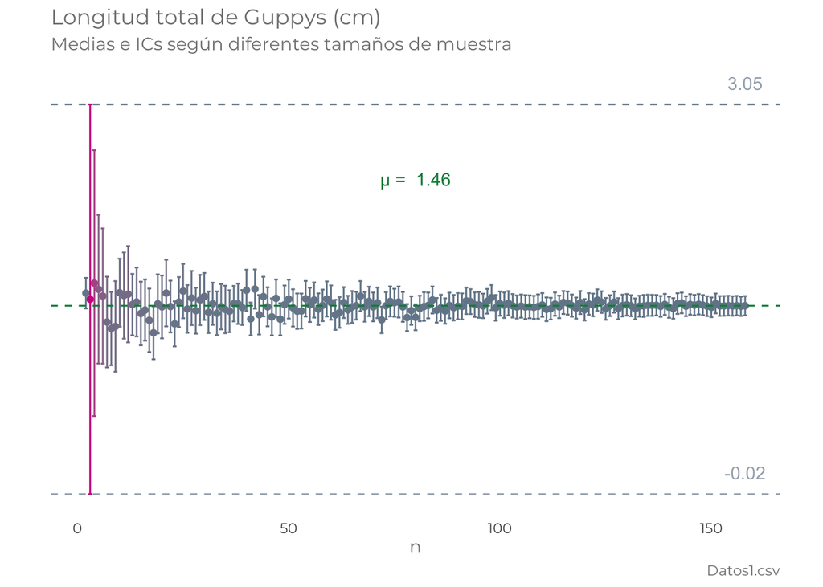